# Risk Factor Analysis

## Outcome Variable

**Outcome Variable:** whz

## Predictor Variables

**Intervention Variable:** fage

**Adjustment Set:**

- arm
- W_mage
- meducyrs
- feducyrs
- W_mhtcm
- W_mwtkg
- W_mbmi
- W_fhtcm
- single
- brthmon
- W_gagebrth
- W_birthwt
- W_birthlen
- vagbrth
- delta_W_mage
- delta_meducyrs
- delta_feducyrs
- delta_W_mhtcm
- delta_W_mwtkg
- delta_W_mbmi
- delta_W_fhtcm
- delta_single
- delta_brthmon
- delta_W_gagebrth
- delta_W_birthwt
- delta_W_birthlen
- delta_vagbrth

## Stratifying Variables

The analysis was stratified on these variable(s):

- agecat
- studyid
- country

## Data Summary

| agecat | studyid | country | fage | n_cell | n |
| --- | --- | --- | --- | --- | --- |
| 6 months | ki0047075b-MAL-ED | BANGLADESH | >=38 | 69 | 150 |
| 6 months | ki0047075b-MAL-ED | BANGLADESH | <32 | 30 | 150 |
| 6 months | ki0047075b-MAL-ED | BANGLADESH | [32-38) | 51 | 150 |
| 6 months | ki0047075b-MAL-ED | BRAZIL | >=38 | 30 | 79 |
| 6 months | ki0047075b-MAL-ED | BRAZIL | <32 | 18 | 79 |
| 6 months | ki0047075b-MAL-ED | BRAZIL | [32-38) | 31 | 79 |
| 6 months | ki0047075b-MAL-ED | INDIA | >=38 | 36 | 161 |
| 6 months | ki0047075b-MAL-ED | INDIA | <32 | 53 | 161 |
| 6 months | ki0047075b-MAL-ED | INDIA | [32-38) | 72 | 161 |
| 6 months | ki0047075b-MAL-ED | NEPAL | >=38 | 17 | 79 |
| 6 months | ki0047075b-MAL-ED | NEPAL | <32 | 15 | 79 |
| 6 months | ki0047075b-MAL-ED | NEPAL | [32-38) | 47 | 79 |
| 6 months | ki0047075b-MAL-ED | PERU | >=38 | 27 | 83 |
| 6 months | ki0047075b-MAL-ED | PERU | <32 | 28 | 83 |
| 6 months | ki0047075b-MAL-ED | PERU | [32-38) | 28 | 83 |
| 6 months | ki0047075b-MAL-ED | SOUTH AFRICA | >=38 | 64 | 89 |
| 6 months | ki0047075b-MAL-ED | SOUTH AFRICA | <32 | 9 | 89 |
| 6 months | ki0047075b-MAL-ED | SOUTH AFRICA | [32-38) | 16 | 89 |
| 6 months | ki0047075b-MAL-ED | TANZANIA, UNITED REPUBLIC OF | >=38 | 48 | 100 |
| 6 months | ki0047075b-MAL-ED | TANZANIA, UNITED REPUBLIC OF | <32 | 15 | 100 |
| 6 months | ki0047075b-MAL-ED | TANZANIA, UNITED REPUBLIC OF | [32-38) | 37 | 100 |
| 6 months | ki1000304b-SAS-CompFeed | INDIA | >=38 | 44 | 1331 |
| 6 months | ki1000304b-SAS-CompFeed | INDIA | <32 | 1122 | 1331 |
| 6 months | ki1000304b-SAS-CompFeed | INDIA | [32-38) | 165 | 1331 |
| 6 months | ki1000304b-SAS-FoodSuppl | INDIA | >=38 | 40 | 380 |
| 6 months | ki1000304b-SAS-FoodSuppl | INDIA | <32 | 264 | 380 |
| 6 months | ki1000304b-SAS-FoodSuppl | INDIA | [32-38) | 76 | 380 |
| 6 months | ki1119695-PROBIT | BELARUS | >=38 | 701 | 15179 |
| 6 months | ki1119695-PROBIT | BELARUS | <32 | 12174 | 15179 |
| 6 months | ki1119695-PROBIT | BELARUS | [32-38) | 2304 | 15179 |
| 6 months | ki1135781-COHORTS | GUATEMALA | >=38 | 276 | 930 |
| 6 months | ki1135781-COHORTS | GUATEMALA | <32 | 421 | 930 |
| 6 months | ki1135781-COHORTS | GUATEMALA | [32-38) | 233 | 930 |
| 6 months | ki1135781-COHORTS | PHILIPPINES | >=38 | 299 | 2622 |
| 6 months | ki1135781-COHORTS | PHILIPPINES | <32 | 1828 | 2622 |
| 6 months | ki1135781-COHORTS | PHILIPPINES | [32-38) | 495 | 2622 |
| 6 months | ki1148112-LCNI-5 | MALAWI | >=38 | 26 | 106 |
| 6 months | ki1148112-LCNI-5 | MALAWI | <32 | 56 | 106 |
| 6 months | ki1148112-LCNI-5 | MALAWI | [32-38) | 24 | 106 |
| 24 months | ki0047075b-MAL-ED | BANGLADESH | >=38 | 69 | 151 |
| 24 months | ki0047075b-MAL-ED | BANGLADESH | <32 | 30 | 151 |
| 24 months | ki0047075b-MAL-ED | BANGLADESH | [32-38) | 52 | 151 |
| 24 months | ki0047075b-MAL-ED | BRAZIL | >=38 | 30 | 79 |
| 24 months | ki0047075b-MAL-ED | BRAZIL | <32 | 18 | 79 |
| 24 months | ki0047075b-MAL-ED | BRAZIL | [32-38) | 31 | 79 |
| 24 months | ki0047075b-MAL-ED | INDIA | >=38 | 36 | 161 |
| 24 months | ki0047075b-MAL-ED | INDIA | <32 | 53 | 161 |
| 24 months | ki0047075b-MAL-ED | INDIA | [32-38) | 72 | 161 |
| 24 months | ki0047075b-MAL-ED | NEPAL | >=38 | 17 | 79 |
| 24 months | ki0047075b-MAL-ED | NEPAL | <32 | 15 | 79 |
| 24 months | ki0047075b-MAL-ED | NEPAL | [32-38) | 47 | 79 |
| 24 months | ki0047075b-MAL-ED | PERU | >=38 | 26 | 79 |
| 24 months | ki0047075b-MAL-ED | PERU | <32 | 27 | 79 |
| 24 months | ki0047075b-MAL-ED | PERU | [32-38) | 26 | 79 |
| 24 months | ki0047075b-MAL-ED | SOUTH AFRICA | >=38 | 65 | 89 |
| 24 months | ki0047075b-MAL-ED | SOUTH AFRICA | <32 | 8 | 89 |
| 24 months | ki0047075b-MAL-ED | SOUTH AFRICA | [32-38) | 16 | 89 |
| 24 months | ki0047075b-MAL-ED | TANZANIA, UNITED REPUBLIC OF | >=38 | 48 | 100 |
| 24 months | ki0047075b-MAL-ED | TANZANIA, UNITED REPUBLIC OF | <32 | 15 | 100 |
| 24 months | ki0047075b-MAL-ED | TANZANIA, UNITED REPUBLIC OF | [32-38) | 37 | 100 |
| 24 months | ki1119695-PROBIT | BELARUS | >=38 | 176 | 3848 |
| 24 months | ki1119695-PROBIT | BELARUS | <32 | 3094 | 3848 |
| 24 months | ki1119695-PROBIT | BELARUS | [32-38) | 578 | 3848 |
| 24 months | ki1135781-COHORTS | GUATEMALA | >=38 | 287 | 1032 |
| 24 months | ki1135781-COHORTS | GUATEMALA | <32 | 495 | 1032 |
| 24 months | ki1135781-COHORTS | GUATEMALA | [32-38) | 250 | 1032 |
| 24 months | ki1135781-COHORTS | PHILIPPINES | >=38 | 271 | 2376 |
| 24 months | ki1135781-COHORTS | PHILIPPINES | <32 | 1670 | 2376 |
| 24 months | ki1135781-COHORTS | PHILIPPINES | [32-38) | 435 | 2376 |
| 24 months | ki1148112-LCNI-5 | MALAWI | >=38 | 21 | 74 |
| 24 months | ki1148112-LCNI-5 | MALAWI | <32 | 37 | 74 |
| 24 months | ki1148112-LCNI-5 | MALAWI | [32-38) | 16 | 74 |

The following strata were considered:

- agecat: 24 months, studyid: ki0047075b-MAL-ED, country: BANGLADESH
- agecat: 24 months, studyid: ki0047075b-MAL-ED, country: BRAZIL
- agecat: 24 months, studyid: ki0047075b-MAL-ED, country: INDIA
- agecat: 24 months, studyid: ki0047075b-MAL-ED, country: NEPAL
- agecat: 24 months, studyid: ki0047075b-MAL-ED, country: PERU
- agecat: 24 months, studyid: ki0047075b-MAL-ED, country: SOUTH AFRICA
- agecat: 24 months, studyid: ki0047075b-MAL-ED, country: TANZANIA, UNITED REPUBLIC OF
- agecat: 24 months, studyid: ki1119695-PROBIT, country: BELARUS
- agecat: 24 months, studyid: ki1135781-COHORTS, country: GUATEMALA
- agecat: 24 months, studyid: ki1135781-COHORTS, country: PHILIPPINES
- agecat: 24 months, studyid: ki1148112-LCNI-5, country: MALAWI
- agecat: 6 months, studyid: ki0047075b-MAL-ED, country: BANGLADESH
- agecat: 6 months, studyid: ki0047075b-MAL-ED, country: BRAZIL
- agecat: 6 months, studyid: ki0047075b-MAL-ED, country: INDIA
- agecat: 6 months, studyid: ki0047075b-MAL-ED, country: NEPAL
- agecat: 6 months, studyid: ki0047075b-MAL-ED, country: PERU
- agecat: 6 months, studyid: ki0047075b-MAL-ED, country: SOUTH AFRICA
- agecat: 6 months, studyid: ki0047075b-MAL-ED, country: TANZANIA, UNITED REPUBLIC OF
- agecat: 6 months, studyid: ki1000304b-SAS-CompFeed, country: INDIA
- agecat: 6 months, studyid: ki1000304b-SAS-FoodSuppl, country: INDIA
- agecat: 6 months, studyid: ki1119695-PROBIT, country: BELARUS
- agecat: 6 months, studyid: ki1135781-COHORTS, country: GUATEMALA
- agecat: 6 months, studyid: ki1135781-COHORTS, country: PHILIPPINES
- agecat: 6 months, studyid: ki1148112-LCNI-5, country: MALAWI

## Methods Detail

We’re interested in the causal parameters $E[Y_a]$ for all values of $a \in \mathcal{A}$. These parameters represent the mean outcome if, possibly contrary to fact, we intervened to set all units to have $A=a$. Under the randomization and positivity assumptions, these are identified by the statistical parameters $\psi_a=E_W[E_{Y|A,W}(Y|A=a,W)]$. In addition, we’re interested in the mean of $Y$, $E[Y]$ under no intervention (the observed mean). We will estimate these parameters by using SuperLearner to fit the relevant likelihood factors – $E_{Y|A,W}(Y|A=a,W)$ and $p(A=a|W)$, and then updating our likelihood fit using a joint TMLE.

For unadjusted analyses ($W=\{\}$), initial likelihoods were estimated using Lrnr_glm to estimate the simple $E(Y|A)$ and Lrnr_mean to estimate $p(A)$. For adjusted analyses, a small library containing Lrnr_glmnet, Lrnr_xgboost, and Lrnr_mean was used.

Having estimated these parameters, we will then use the delta method to estimate relative risks and attributable risks relative to a prespecified baseline level of $A$.

# Results Detail

## Results Plots

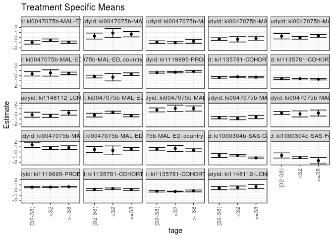

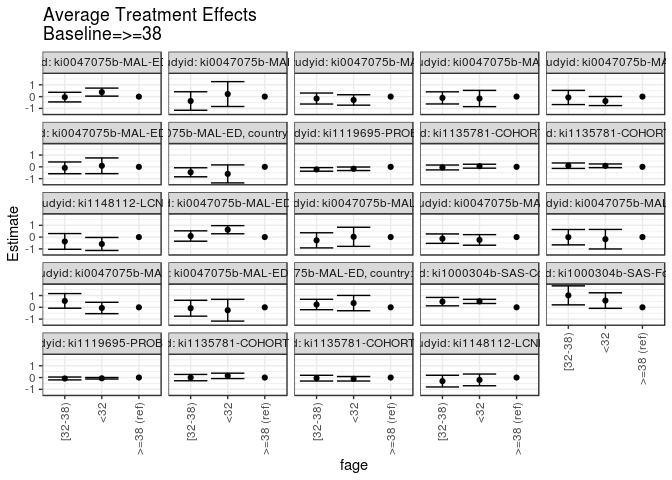

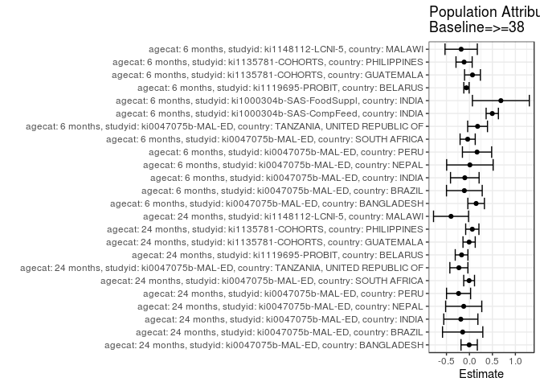

## Results Table

### Parameter: TSM

| agecat | studyid | country | intervention_level | baseline_level | estimate | ci_lower | ci_upper |
| --- | --- | --- | --- | --- | --- | --- | --- |
| 6 months | ki0047075b-MAL-ED | BANGLADESH | >=38 | NA | -0.3433771 | -0.5840803 | -0.1026739 |
| 6 months | ki0047075b-MAL-ED | BANGLADESH | <32 | NA | 0.2844895 | 0.0353242 | 0.5336548 |
| 6 months | ki0047075b-MAL-ED | BANGLADESH | [32-38) | NA | -0.2521304 | -0.6210591 | 0.1167982 |
| 6 months | ki0047075b-MAL-ED | BRAZIL | >=38 | NA | 1.0501052 | 0.5429042 | 1.5573061 |
| 6 months | ki0047075b-MAL-ED | BRAZIL | <32 | NA | 1.0735118 | 0.4328968 | 1.7141268 |
| 6 months | ki0047075b-MAL-ED | BRAZIL | [32-38) | NA | 0.7728870 | 0.3818843 | 1.1638897 |
| 6 months | ki0047075b-MAL-ED | INDIA | >=38 | NA | -0.6198012 | -0.9497146 | -0.2898879 |
| 6 months | ki0047075b-MAL-ED | INDIA | <32 | NA | -0.8597855 | -1.1586560 | -0.5609150 |
| 6 months | ki0047075b-MAL-ED | INDIA | [32-38) | NA | -0.7526502 | -0.9793038 | -0.5259967 |
| 6 months | ki0047075b-MAL-ED | NEPAL | >=38 | NA | 0.1675916 | -0.4181678 | 0.7533511 |
| 6 months | ki0047075b-MAL-ED | NEPAL | <32 | NA | -0.0108425 | -0.6073121 | 0.5856271 |
| 6 months | ki0047075b-MAL-ED | NEPAL | [32-38) | NA | 0.1595197 | -0.1490059 | 0.4680454 |
| 6 months | ki0047075b-MAL-ED | PERU | >=38 | NA | 0.8485847 | 0.4819475 | 1.2152218 |
| 6 months | ki0047075b-MAL-ED | PERU | <32 | NA | 0.7914984 | 0.4762368 | 1.1067601 |
| 6 months | ki0047075b-MAL-ED | PERU | [32-38) | NA | 1.3935016 | 0.8936236 | 1.8933796 |
| 6 months | ki0047075b-MAL-ED | SOUTH AFRICA | >=38 | NA | 0.5540104 | 0.2423876 | 0.8656332 |
| 6 months | ki0047075b-MAL-ED | SOUTH AFRICA | <32 | NA | 0.3072222 | -0.5631094 | 1.1775539 |
| 6 months | ki0047075b-MAL-ED | SOUTH AFRICA | [32-38) | NA | 0.4778125 | -0.1195388 | 1.0751638 |
| 6 months | ki0047075b-MAL-ED | TANZANIA, UNITED REPUBLIC OF | >=38 | NA | 0.3262887 | 0.0271688 | 0.6254086 |
| 6 months | ki0047075b-MAL-ED | TANZANIA, UNITED REPUBLIC OF | <32 | NA | 0.6851834 | 0.1083378 | 1.2620290 |
| 6 months | ki0047075b-MAL-ED | TANZANIA, UNITED REPUBLIC OF | [32-38) | NA | 0.5644673 | 0.2299667 | 0.8989678 |
| 6 months | ki1000304b-SAS-CompFeed | INDIA | >=38 | NA | -1.1608921 | -1.3394886 | -0.9822956 |
| 6 months | ki1000304b-SAS-CompFeed | INDIA | <32 | NA | -0.6590898 | -0.7953106 | -0.5228691 |
| 6 months | ki1000304b-SAS-CompFeed | INDIA | [32-38) | NA | -0.6781953 | -1.0876468 | -0.2687438 |
| 6 months | ki1000304b-SAS-FoodSuppl | INDIA | >=38 | NA | -1.6963449 | -2.3272480 | -1.0654417 |
| 6 months | ki1000304b-SAS-FoodSuppl | INDIA | <32 | NA | -1.1234945 | -1.3102236 | -0.9367654 |
| 6 months | ki1000304b-SAS-FoodSuppl | INDIA | [32-38) | NA | -0.6826938 | -1.1816543 | -0.1837333 |
| 6 months | ki1119695-PROBIT | BELARUS | >=38 | NA | 0.6429183 | 0.5863870 | 0.6994495 |
| 6 months | ki1119695-PROBIT | BELARUS | <32 | NA | 0.5802420 | 0.5159673 | 0.6445166 |
| 6 months | ki1119695-PROBIT | BELARUS | [32-38) | NA | 0.5643146 | 0.4547630 | 0.6738662 |
| 6 months | ki1135781-COHORTS | GUATEMALA | >=38 | NA | 0.1262388 | -0.0599560 | 0.3124335 |
| 6 months | ki1135781-COHORTS | GUATEMALA | <32 | NA | 0.2688904 | 0.1352849 | 0.4024958 |
| 6 months | ki1135781-COHORTS | GUATEMALA | [32-38) | NA | 0.1226282 | -0.0700267 | 0.3152831 |
| 6 months | ki1135781-COHORTS | PHILIPPINES | >=38 | NA | -0.1713081 | -0.3515157 | 0.0088996 |
| 6 months | ki1135781-COHORTS | PHILIPPINES | <32 | NA | -0.2770738 | -0.3411879 | -0.2129597 |
| 6 months | ki1135781-COHORTS | PHILIPPINES | [32-38) | NA | -0.2238578 | -0.3869292 | -0.0607864 |
| 6 months | ki1148112-LCNI-5 | MALAWI | >=38 | NA | 0.6859192 | 0.2971921 | 1.0746464 |
| 6 months | ki1148112-LCNI-5 | MALAWI | <32 | NA | 0.4861794 | 0.1811531 | 0.7912057 |
| 6 months | ki1148112-LCNI-5 | MALAWI | [32-38) | NA | 0.3823042 | 0.0736058 | 0.6910025 |
| 24 months | ki0047075b-MAL-ED | BANGLADESH | >=38 | NA | -0.8801469 | -1.1013718 | -0.6589220 |
| 24 months | ki0047075b-MAL-ED | BANGLADESH | <32 | NA | -0.4986213 | -0.7493275 | -0.2479151 |
| 24 months | ki0047075b-MAL-ED | BANGLADESH | [32-38) | NA | -0.9224165 | -1.2594506 | -0.5853823 |
| 24 months | ki0047075b-MAL-ED | BRAZIL | >=38 | NA | 0.6915448 | 0.1527192 | 1.2303704 |
| 24 months | ki0047075b-MAL-ED | BRAZIL | <32 | NA | 0.9092283 | 0.0060707 | 1.8123859 |
| 24 months | ki0047075b-MAL-ED | BRAZIL | [32-38) | NA | 0.3181613 | -0.2688909 | 0.9052136 |
| 24 months | ki0047075b-MAL-ED | INDIA | >=38 | NA | -0.7102391 | -1.0997897 | -0.3206886 |
| 24 months | ki0047075b-MAL-ED | INDIA | <32 | NA | -0.9921065 | -1.2024434 | -0.7817696 |
| 24 months | ki0047075b-MAL-ED | INDIA | [32-38) | NA | -0.8718162 | -1.1225962 | -0.6210362 |
| 24 months | ki0047075b-MAL-ED | NEPAL | >=38 | NA | -0.1591727 | -0.6065154 | 0.2881700 |
| 24 months | ki0047075b-MAL-ED | NEPAL | <32 | NA | -0.3205444 | -0.8429565 | 0.2018677 |
| 24 months | ki0047075b-MAL-ED | NEPAL | [32-38) | NA | -0.2688569 | -0.5192047 | -0.0185092 |
| 24 months | ki0047075b-MAL-ED | PERU | >=38 | NA | 0.3569759 | 0.0849884 | 0.6289635 |
| 24 months | ki0047075b-MAL-ED | PERU | <32 | NA | -0.0167427 | -0.2865963 | 0.2531109 |
| 24 months | ki0047075b-MAL-ED | PERU | [32-38) | NA | 0.2849932 | -0.2516911 | 0.8216774 |
| 24 months | ki0047075b-MAL-ED | SOUTH AFRICA | >=38 | NA | 0.4608462 | 0.2091394 | 0.7125530 |
| 24 months | ki0047075b-MAL-ED | SOUTH AFRICA | <32 | NA | 0.5500000 | -0.0688276 | 1.1688276 |
| 24 months | ki0047075b-MAL-ED | SOUTH AFRICA | [32-38) | NA | 0.3771875 | -0.0538993 | 0.8082743 |
| 24 months | ki0047075b-MAL-ED | TANZANIA, UNITED REPUBLIC OF | >=38 | NA | 0.3063342 | 0.0417355 | 0.5709329 |
| 24 months | ki0047075b-MAL-ED | TANZANIA, UNITED REPUBLIC OF | <32 | NA | -0.2916158 | -1.0088740 | 0.4256424 |
| 24 months | ki0047075b-MAL-ED | TANZANIA, UNITED REPUBLIC OF | [32-38) | NA | -0.1545120 | -0.4296140 | 0.1205901 |
| 24 months | ki1119695-PROBIT | BELARUS | >=38 | NA | 0.8556814 | 0.7011967 | 1.0101661 |
| 24 months | ki1119695-PROBIT | BELARUS | <32 | NA | 0.6922418 | 0.5746339 | 0.8098497 |
| 24 months | ki1119695-PROBIT | BELARUS | [32-38) | NA | 0.6376047 | 0.5115122 | 0.7636972 |
| 24 months | ki1135781-COHORTS | GUATEMALA | >=38 | NA | -0.2689237 | -0.4112230 | -0.1266244 |
| 24 months | ki1135781-COHORTS | GUATEMALA | <32 | NA | -0.2145150 | -0.3032809 | -0.1257491 |
| 24 months | ki1135781-COHORTS | GUATEMALA | [32-38) | NA | -0.3200317 | -0.4708484 | -0.1692150 |
| 24 months | ki1135781-COHORTS | PHILIPPINES | >=38 | NA | -0.6710696 | -0.8177543 | -0.5243849 |
| 24 months | ki1135781-COHORTS | PHILIPPINES | <32 | NA | -0.5825855 | -0.6384119 | -0.5267591 |
| 24 months | ki1135781-COHORTS | PHILIPPINES | [32-38) | NA | -0.5730299 | -0.7523945 | -0.3936653 |
| 24 months | ki1148112-LCNI-5 | MALAWI | >=38 | NA | 0.2021785 | -0.2527789 | 0.6571358 |
| 24 months | ki1148112-LCNI-5 | MALAWI | <32 | NA | -0.3823670 | -0.6948456 | -0.0698884 |
| 24 months | ki1148112-LCNI-5 | MALAWI | [32-38) | NA | -0.1677032 | -0.6558678 | 0.3204614 |

### Parameter: E(Y)

| agecat | studyid | country | intervention_level | baseline_level | estimate | ci_lower | ci_upper |
| --- | --- | --- | --- | --- | --- | --- | --- |
| 6 months | ki0047075b-MAL-ED | BANGLADESH | NA | NA | -0.1977833 | -0.3606366 | -0.0349301 |
| 6 months | ki0047075b-MAL-ED | BRAZIL | NA | NA | 0.9393882 | 0.6572880 | 1.2214884 |
| 6 months | ki0047075b-MAL-ED | INDIA | NA | NA | -0.7206832 | -0.8692329 | -0.5721336 |
| 6 months | ki0047075b-MAL-ED | NEPAL | NA | NA | 0.1778270 | -0.0614697 | 0.4171237 |
| 6 months | ki0047075b-MAL-ED | PERU | NA | NA | 1.0140361 | 0.7785203 | 1.2495520 |
| 6 months | ki0047075b-MAL-ED | SOUTH AFRICA | NA | NA | 0.5153558 | 0.2512666 | 0.7794450 |
| 6 months | ki0047075b-MAL-ED | TANZANIA, UNITED REPUBLIC OF | NA | NA | 0.5034500 | 0.2959923 | 0.7109077 |
| 6 months | ki1000304b-SAS-CompFeed | INDIA | NA | NA | -0.6641059 | -0.8040033 | -0.5242086 |
| 6 months | ki1000304b-SAS-FoodSuppl | INDIA | NA | NA | -1.0121579 | -1.1280429 | -0.8962729 |
| 6 months | ki1119695-PROBIT | BELARUS | NA | NA | 0.5783069 | 0.5185614 | 0.6380524 |
| 6 months | ki1135781-COHORTS | GUATEMALA | NA | NA | 0.1925914 | 0.1205037 | 0.2646791 |
| 6 months | ki1135781-COHORTS | PHILIPPINES | NA | NA | -0.2878032 | -0.3296319 | -0.2459745 |
| 6 months | ki1148112-LCNI-5 | MALAWI | NA | NA | 0.5058491 | 0.3128980 | 0.6988001 |
| 24 months | ki0047075b-MAL-ED | BANGLADESH | NA | NA | -0.8861589 | -1.0281048 | -0.7442131 |
| 24 months | ki0047075b-MAL-ED | BRAZIL | NA | NA | 0.5441139 | 0.2074310 | 0.8807969 |
| 24 months | ki0047075b-MAL-ED | INDIA | NA | NA | -0.8977019 | -1.0295625 | -0.7658412 |
| 24 months | ki0047075b-MAL-ED | NEPAL | NA | NA | -0.2838608 | -0.4798646 | -0.0878569 |
| 24 months | ki0047075b-MAL-ED | PERU | NA | NA | 0.1203797 | -0.0839887 | 0.3247482 |
| 24 months | ki0047075b-MAL-ED | SOUTH AFRICA | NA | NA | 0.4538202 | 0.2465091 | 0.6611314 |
| 24 months | ki0047075b-MAL-ED | TANZANIA, UNITED REPUBLIC OF | NA | NA | 0.0766500 | -0.1115307 | 0.2648307 |
| 24 months | ki1119695-PROBIT | BELARUS | NA | NA | 0.6846323 | 0.5733690 | 0.7958955 |
| 24 months | ki1135781-COHORTS | GUATEMALA | NA | NA | -0.2760853 | -0.3311930 | -0.2209775 |
| 24 months | ki1135781-COHORTS | PHILIPPINES | NA | NA | -0.6087584 | -0.6459824 | -0.5715345 |
| 24 months | ki1148112-LCNI-5 | MALAWI | NA | NA | -0.1982432 | -0.4246666 | 0.0281801 |

### Parameter: ATE

| agecat | studyid | country | intervention_level | baseline_level | estimate | ci_lower | ci_upper |
| --- | --- | --- | --- | --- | --- | --- | --- |
| 6 months | ki0047075b-MAL-ED | BANGLADESH | >=38 | >=38 | 0.0000000 | 0.0000000 | 0.0000000 |
| 6 months | ki0047075b-MAL-ED | BANGLADESH | <32 | >=38 | 0.6278666 | 0.2825644 | 0.9731689 |
| 6 months | ki0047075b-MAL-ED | BANGLADESH | [32-38) | >=38 | 0.0912467 | -0.3493348 | 0.5318282 |
| 6 months | ki0047075b-MAL-ED | BRAZIL | >=38 | >=38 | 0.0000000 | 0.0000000 | 0.0000000 |
| 6 months | ki0047075b-MAL-ED | BRAZIL | <32 | >=38 | 0.0234066 | -0.7865947 | 0.8334079 |
| 6 months | ki0047075b-MAL-ED | BRAZIL | [32-38) | >=38 | -0.2772182 | -0.9193809 | 0.3649445 |
| 6 months | ki0047075b-MAL-ED | INDIA | >=38 | >=38 | 0.0000000 | 0.0000000 | 0.0000000 |
| 6 months | ki0047075b-MAL-ED | INDIA | <32 | >=38 | -0.2399843 | -0.6878456 | 0.2078771 |
| 6 months | ki0047075b-MAL-ED | INDIA | [32-38) | >=38 | -0.1328490 | -0.5331795 | 0.2674815 |
| 6 months | ki0047075b-MAL-ED | NEPAL | >=38 | >=38 | 0.0000000 | 0.0000000 | 0.0000000 |
| 6 months | ki0047075b-MAL-ED | NEPAL | <32 | >=38 | -0.1784341 | -1.0075805 | 0.6507123 |
| 6 months | ki0047075b-MAL-ED | NEPAL | [32-38) | >=38 | -0.0080719 | -0.6603841 | 0.6442404 |
| 6 months | ki0047075b-MAL-ED | PERU | >=38 | >=38 | 0.0000000 | 0.0000000 | 0.0000000 |
| 6 months | ki0047075b-MAL-ED | PERU | <32 | >=38 | -0.0570862 | -0.5397820 | 0.4256096 |
| 6 months | ki0047075b-MAL-ED | PERU | [32-38) | >=38 | 0.5449170 | -0.0755268 | 1.1653607 |
| 6 months | ki0047075b-MAL-ED | SOUTH AFRICA | >=38 | >=38 | 0.0000000 | 0.0000000 | 0.0000000 |
| 6 months | ki0047075b-MAL-ED | SOUTH AFRICA | <32 | >=38 | -0.2467882 | -1.1712264 | 0.6776500 |
| 6 months | ki0047075b-MAL-ED | SOUTH AFRICA | [32-38) | >=38 | -0.0761979 | -0.7499466 | 0.5975508 |
| 6 months | ki0047075b-MAL-ED | TANZANIA, UNITED REPUBLIC OF | >=38 | >=38 | 0.0000000 | 0.0000000 | 0.0000000 |
| 6 months | ki0047075b-MAL-ED | TANZANIA, UNITED REPUBLIC OF | <32 | >=38 | 0.3588947 | -0.2908651 | 1.0086545 |
| 6 months | ki0047075b-MAL-ED | TANZANIA, UNITED REPUBLIC OF | [32-38) | >=38 | 0.2381786 | -0.2035094 | 0.6798666 |
| 6 months | ki1000304b-SAS-CompFeed | INDIA | >=38 | >=38 | 0.0000000 | 0.0000000 | 0.0000000 |
| 6 months | ki1000304b-SAS-CompFeed | INDIA | <32 | >=38 | 0.5018022 | 0.3254880 | 0.6781165 |
| 6 months | ki1000304b-SAS-CompFeed | INDIA | [32-38) | >=38 | 0.4826968 | 0.1269131 | 0.8384806 |
| 6 months | ki1000304b-SAS-FoodSuppl | INDIA | >=38 | >=38 | 0.0000000 | 0.0000000 | 0.0000000 |
| 6 months | ki1000304b-SAS-FoodSuppl | INDIA | <32 | >=38 | 0.5728503 | -0.0866759 | 1.2323766 |
| 6 months | ki1000304b-SAS-FoodSuppl | INDIA | [32-38) | >=38 | 1.0136510 | 0.2081934 | 1.8191087 |
| 6 months | ki1119695-PROBIT | BELARUS | >=38 | >=38 | 0.0000000 | 0.0000000 | 0.0000000 |
| 6 months | ki1119695-PROBIT | BELARUS | <32 | >=38 | -0.0626763 | -0.1259385 | 0.0005859 |
| 6 months | ki1119695-PROBIT | BELARUS | [32-38) | >=38 | -0.0786037 | -0.1991420 | 0.0419346 |
| 6 months | ki1135781-COHORTS | GUATEMALA | >=38 | >=38 | 0.0000000 | 0.0000000 | 0.0000000 |
| 6 months | ki1135781-COHORTS | GUATEMALA | <32 | >=38 | 0.1426516 | -0.0865931 | 0.3718963 |
| 6 months | ki1135781-COHORTS | GUATEMALA | [32-38) | >=38 | -0.0036106 | -0.2719058 | 0.2646847 |
| 6 months | ki1135781-COHORTS | PHILIPPINES | >=38 | >=38 | 0.0000000 | 0.0000000 | 0.0000000 |
| 6 months | ki1135781-COHORTS | PHILIPPINES | <32 | >=38 | -0.1057657 | -0.2968672 | 0.0853358 |
| 6 months | ki1135781-COHORTS | PHILIPPINES | [32-38) | >=38 | -0.0525498 | -0.2954272 | 0.1903277 |
| 6 months | ki1148112-LCNI-5 | MALAWI | >=38 | >=38 | 0.0000000 | 0.0000000 | 0.0000000 |
| 6 months | ki1148112-LCNI-5 | MALAWI | <32 | >=38 | -0.1997399 | -0.6988706 | 0.2993908 |
| 6 months | ki1148112-LCNI-5 | MALAWI | [32-38) | >=38 | -0.3036151 | -0.8000271 | 0.1927969 |
| 24 months | ki0047075b-MAL-ED | BANGLADESH | >=38 | >=38 | 0.0000000 | 0.0000000 | 0.0000000 |
| 24 months | ki0047075b-MAL-ED | BANGLADESH | <32 | >=38 | 0.3815256 | 0.0413211 | 0.7217301 |
| 24 months | ki0047075b-MAL-ED | BANGLADESH | [32-38) | >=38 | -0.0422696 | -0.4511910 | 0.3666519 |
| 24 months | ki0047075b-MAL-ED | BRAZIL | >=38 | >=38 | 0.0000000 | 0.0000000 | 0.0000000 |
| 24 months | ki0047075b-MAL-ED | BRAZIL | <32 | >=38 | 0.2176835 | -0.8370887 | 1.2724557 |
| 24 months | ki0047075b-MAL-ED | BRAZIL | [32-38) | >=38 | -0.3733835 | -1.1576201 | 0.4108532 |
| 24 months | ki0047075b-MAL-ED | INDIA | >=38 | >=38 | 0.0000000 | 0.0000000 | 0.0000000 |
| 24 months | ki0047075b-MAL-ED | INDIA | <32 | >=38 | -0.2818673 | -0.7251618 | 0.1614271 |
| 24 months | ki0047075b-MAL-ED | INDIA | [32-38) | >=38 | -0.1615770 | -0.6274206 | 0.3042665 |
| 24 months | ki0047075b-MAL-ED | NEPAL | >=38 | >=38 | 0.0000000 | 0.0000000 | 0.0000000 |
| 24 months | ki0047075b-MAL-ED | NEPAL | <32 | >=38 | -0.1613717 | -0.8499631 | 0.5272198 |
| 24 months | ki0047075b-MAL-ED | NEPAL | [32-38) | >=38 | -0.1096842 | -0.6241106 | 0.4047421 |
| 24 months | ki0047075b-MAL-ED | PERU | >=38 | >=38 | 0.0000000 | 0.0000000 | 0.0000000 |
| 24 months | ki0047075b-MAL-ED | PERU | <32 | >=38 | -0.3737187 | -0.7595982 | 0.0121609 |
| 24 months | ki0047075b-MAL-ED | PERU | [32-38) | >=38 | -0.0719828 | -0.6725588 | 0.5285932 |
| 24 months | ki0047075b-MAL-ED | SOUTH AFRICA | >=38 | >=38 | 0.0000000 | 0.0000000 | 0.0000000 |
| 24 months | ki0047075b-MAL-ED | SOUTH AFRICA | <32 | >=38 | 0.0891538 | -0.5789059 | 0.7572136 |
| 24 months | ki0047075b-MAL-ED | SOUTH AFRICA | [32-38) | >=38 | -0.0836587 | -0.5828501 | 0.4155328 |
| 24 months | ki0047075b-MAL-ED | TANZANIA, UNITED REPUBLIC OF | >=38 | >=38 | 0.0000000 | 0.0000000 | 0.0000000 |
| 24 months | ki0047075b-MAL-ED | TANZANIA, UNITED REPUBLIC OF | <32 | >=38 | -0.5979500 | -1.3614136 | 0.1655136 |
| 24 months | ki0047075b-MAL-ED | TANZANIA, UNITED REPUBLIC OF | [32-38) | >=38 | -0.4608462 | -0.8430617 | -0.0786307 |
| 24 months | ki1119695-PROBIT | BELARUS | >=38 | >=38 | 0.0000000 | 0.0000000 | 0.0000000 |
| 24 months | ki1119695-PROBIT | BELARUS | <32 | >=38 | -0.1634397 | -0.3115592 | -0.0153201 |
| 24 months | ki1119695-PROBIT | BELARUS | [32-38) | >=38 | -0.2180767 | -0.3694460 | -0.0667075 |
| 24 months | ki1135781-COHORTS | GUATEMALA | >=38 | >=38 | 0.0000000 | 0.0000000 | 0.0000000 |
| 24 months | ki1135781-COHORTS | GUATEMALA | <32 | >=38 | 0.0544087 | -0.1132572 | 0.2220746 |
| 24 months | ki1135781-COHORTS | GUATEMALA | [32-38) | >=38 | -0.0511081 | -0.2585148 | 0.1562986 |
| 24 months | ki1135781-COHORTS | PHILIPPINES | >=38 | >=38 | 0.0000000 | 0.0000000 | 0.0000000 |
| 24 months | ki1135781-COHORTS | PHILIPPINES | <32 | >=38 | 0.0884840 | -0.0682402 | 0.2452083 |
| 24 months | ki1135781-COHORTS | PHILIPPINES | [32-38) | >=38 | 0.0980396 | -0.1334966 | 0.3295759 |
| 24 months | ki1148112-LCNI-5 | MALAWI | >=38 | >=38 | 0.0000000 | 0.0000000 | 0.0000000 |
| 24 months | ki1148112-LCNI-5 | MALAWI | <32 | >=38 | -0.5845455 | -1.1360831 | -0.0330078 |
| 24 months | ki1148112-LCNI-5 | MALAWI | [32-38) | >=38 | -0.3698817 | -1.0367188 | 0.2969555 |

### Parameter: PAR

| agecat | studyid | country | intervention_level | baseline_level | estimate | ci_lower | ci_upper |
| --- | --- | --- | --- | --- | --- | --- | --- |
| 6 months | ki0047075b-MAL-ED | BANGLADESH | >=38 | NA | 0.1455938 | -0.0346507 | 0.3258383 |
| 6 months | ki0047075b-MAL-ED | BRAZIL | >=38 | NA | -0.1107170 | -0.4995841 | 0.2781501 |
| 6 months | ki0047075b-MAL-ED | INDIA | >=38 | NA | -0.1008820 | -0.4119225 | 0.2101585 |
| 6 months | ki0047075b-MAL-ED | NEPAL | >=38 | NA | 0.0102354 | -0.4958745 | 0.5163452 |
| 6 months | ki0047075b-MAL-ED | PERU | >=38 | NA | 0.1654515 | -0.1527040 | 0.4836070 |
| 6 months | ki0047075b-MAL-ED | SOUTH AFRICA | >=38 | NA | -0.0386546 | -0.2035480 | 0.1262388 |
| 6 months | ki0047075b-MAL-ED | TANZANIA, UNITED REPUBLIC OF | >=38 | NA | 0.1771613 | -0.0384379 | 0.3927605 |
| 6 months | ki1000304b-SAS-CompFeed | INDIA | >=38 | NA | 0.4967862 | 0.3632714 | 0.6303009 |
| 6 months | ki1000304b-SAS-FoodSuppl | INDIA | >=38 | NA | 0.6841870 | 0.0647230 | 1.3036509 |
| 6 months | ki1119695-PROBIT | BELARUS | >=38 | NA | -0.0646114 | -0.1223882 | -0.0068346 |
| 6 months | ki1135781-COHORTS | GUATEMALA | >=38 | NA | 0.0663526 | -0.1061136 | 0.2388189 |
| 6 months | ki1135781-COHORTS | PHILIPPINES | >=38 | NA | -0.1164951 | -0.2924865 | 0.0594963 |
| 6 months | ki1148112-LCNI-5 | MALAWI | >=38 | NA | -0.1800702 | -0.5314785 | 0.1713382 |
| 24 months | ki0047075b-MAL-ED | BANGLADESH | >=38 | NA | -0.0060120 | -0.1834582 | 0.1714341 |
| 24 months | ki0047075b-MAL-ED | BRAZIL | >=38 | NA | -0.1474309 | -0.5859142 | 0.2910524 |
| 24 months | ki0047075b-MAL-ED | INDIA | >=38 | NA | -0.1874627 | -0.5587582 | 0.1838327 |
| 24 months | ki0047075b-MAL-ED | NEPAL | >=38 | NA | -0.1246881 | -0.5182086 | 0.2688325 |
| 24 months | ki0047075b-MAL-ED | PERU | >=38 | NA | -0.2365962 | -0.4985961 | 0.0254037 |
| 24 months | ki0047075b-MAL-ED | SOUTH AFRICA | >=38 | NA | -0.0070259 | -0.1244623 | 0.1104104 |
| 24 months | ki0047075b-MAL-ED | TANZANIA, UNITED REPUBLIC OF | >=38 | NA | -0.2296842 | -0.4260024 | -0.0333660 |
| 24 months | ki1119695-PROBIT | BELARUS | >=38 | NA | -0.1710492 | -0.3090191 | -0.0330792 |
| 24 months | ki1135781-COHORTS | GUATEMALA | >=38 | NA | -0.0071616 | -0.1403979 | 0.1260747 |
| 24 months | ki1135781-COHORTS | PHILIPPINES | >=38 | NA | 0.0623111 | -0.0816794 | 0.2063017 |
| 24 months | ki1148112-LCNI-5 | MALAWI | >=38 | NA | -0.4004217 | -0.7816324 | -0.0192110 |